# SMMS Sternite Dataset Analysis

Gregory K. Ross

University of Florida  
gkross@ufl.edu

# Introduction

```r
knitr::include_graphics(rep("FMEL.jpg", 1))
```

[output not shown]

This analysis was performed by the University of Florida - Florida Medical Entomology Laboratory, 200 9th Street SE, Vero Becah FL, 32962. This analysis is done in a reproducible research manner. All Tables, Figures and Statistical Analyses were created in the open source software package R.

**Date:** 10/26/2016

**Version:** 2.0

# Data

A copy of this data analysis (PDF) may be downloaded [here](https://gatorbox.rc.ufl.edu/index.php/s/tYayMuuQ8iowUd8).

A copy of the original data (XLSX) may be downloaded [here](https://gatorbox.rc.ufl.edu/index.php/s/aStOBibUNnTcPDJ).

A copy of the cleaned data (CSV) used for the analysis may be downloaded [here](https://gatorbox.rc.ufl.edu/index.php/s/iMHCgooLtCEpN6Y).

# Analysis

```r
sternite <- read_csv("sternite.csv")
attach(sternite)
SPECIES<-as.factor(SPECIES)
AEG <- subset(sternite, sternite$SPECIES=="AEG")
ALB <- subset(sternite, sternite$SPECIES=="ALB")
AEGMosaic <- structable(AEG$SCUTUM ~ AEG$STERGUM)
ALBMosaic <- structable(ALB$SCUTUM ~ ALB$STERGUM)
StergumMosaic <- structable(STERGUM ~ SPECIES)
StergumMosaic2 <- table(SPECIES,STERGUM)
ScutumMosaic <- structable(SCUTUM ~ SPECIES)
ScutumMosaic2 <- table(SPECIES,SCUTUM)
```

## AEG/ALB Analysis (Both Species)

### AEG/ALB Data Summary

```r
pander(summary(sternite[,4:5]), caption = "Table 1. Summary of Sternite Dataset", split.table = Inf)
```

```
---------------------------------
     SCUTUM          STERGUM
---------------- ----------------
 Min.  :0.0000    Min.  :0.0000

 1st Qu.:0.1000   1st Qu.:0.8000

 Median :0.2000   Median :1.0000

  Mean :0.3372     Mean :0.8665

 3rd Qu.:0.6000   3rd Qu.:1.0000

 Max.  :1.0000    Max.  :1.0000
---------------------------------

Table: Table 1. Summary of Sternite Dataset
```

### AEG/ALB Data Description

```r
pander(describe(sternite[,4:5]), caption = "Table 2. Description of Sternite Dataset", split.table = Inf)
```

```
----------------------------------------------------------------------------------------------------------------------------
   &nbsp;      vars    n      mean      sd     median   trimmed    mad     min   max   range    skew    kurtosis      se
------------- ------ ------ -------- -------- -------- --------- -------- ----- ----- ------- -------- ---------- ----------
 **SCUTUM**     1     1241   0.3372   0.3283    0.2     0.3015    0.2965    0     1      1     0.7975   -0.8095    0.00932

 **STERGUM**    2     1241   0.8665   0.226      1      0.9224      0       0     1      1     -2.042    3.381     0.006415
----------------------------------------------------------------------------------------------------------------------------

Table: Table 2. Description of Sternite Dataset
```

### AEG/ALB Data Dispersion

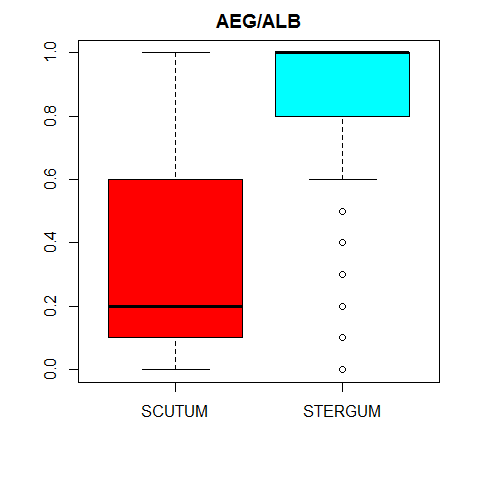

```r
boxplot(sternite[,4:5], col=rainbow(2), main="AEG/ALB")
```

### AEG/ALB Data Distribution

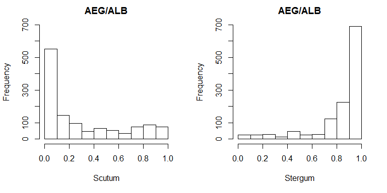

```r
par(mfrow=c(1,2))
hist(sternite$SCUTUM, xlab="Scutum", main="AEG/ALB", ylim = c(0, 700))
hist(sternite$STERGUM, xlab="Stergum", main="AEG/ALB", ylim = c(0, 700))
```

### AEG/ALB Hexbin of Scutum vs Stergum

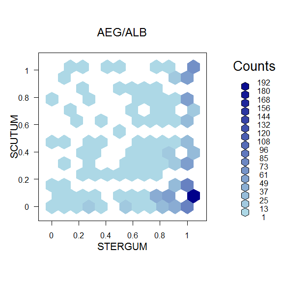

```r
res <- hexbin(STERGUM, SCUTUM, xbins=11)
plot(res, main="AEG/ALB", colramp=colorRampPalette(c('lightblue','darkblue')))
```

### AEG/ALB Analysis Discussion

When looking at both species as a collective dataset, the scutum and stergum data appear to be heavily skewed, though in opposite directions. Figure 3 indicates that when the stergum is skewed in the direction of 100% coverage and the scutum is skewed in the direction of 0% coverage.

## AEG Analysis

### AEG Data Summary

```r
pander(summary(AEG[,4:5]), caption = "Table 3. Summary of AEG Dataset", split.table = Inf)
```

```
---------------------------------
     SCUTUM          STERGUM
---------------- ----------------
 Min.  :0.0000    Min.  :0.0000

 1st Qu.:0.4000   1st Qu.:0.9000

 Median :0.6000   Median :1.0000

  Mean :0.6026     Mean :0.9132

 3rd Qu.:0.9000   3rd Qu.:1.0000

 Max.  :1.0000    Max.  :1.0000
---------------------------------

Table: Table 3. Summary of AEG Dataset
```

### AEG Data Description

```r
pander(describe(AEG[,4:5]), caption = "Table 4. Description of AEG Dataset", split.table = Inf)
```

```
---------------------------------------------------------------------------------------------------------------------------
   &nbsp;      vars    n     mean      sd     median   trimmed    mad     min   max   range    skew     kurtosis     se
------------- ------ ----- -------- -------- -------- --------- -------- ----- ----- ------- --------- ---------- ---------
 **SCUTUM**     1     227   0.6026   0.2969    0.6     0.6224    0.2965    0     1      1     -0.4569   -0.8901    0.0197

 **STERGUM**    2     227   0.9132   0.1735     1      0.9552      0       0     1      1     -3.094     10.62     0.01151
---------------------------------------------------------------------------------------------------------------------------

Table: Table 4. Description of AEG Dataset
```

### AEG Data Frequency Counts

```r
pander(ftable(AEGMosaic), caption = "Table 5. AEG Frequencies", split.table = Inf)
```

```
------------- ------------ --- ----- ----- ----- ----- ----- ----- ----- ----- ----- ----
               AEG$SCUTUM   0   0.1   0.2   0.3   0.4   0.5   0.6   0.7   0.8   0.9   1

 AEG$STERGUM

      0                     1    0     0     0     0     1     0     0     0     0    0

     0.1                    0    0     0     1     0     0     0     0     0     0    0

     0.2                    1    0     0     0     0     0     0     0     0     0    0

     0.3                    2    0     0     0     1     0     0     0     1     0    0

     0.5                    0    1     0     0     0     1     0     0     0     1    0

     0.6                    0    0     0     0     1     1     1     0     1     0    0

     0.7                    1    0     0     1     1     0     1     0     0     1    0

     0.8                    3    3     1     1     1     3     1     1     4     1    1

     0.9                    1    0     4     6     3     6     4     5     4    11    2

      1                     4    6     4    11    11    10    16    14    22    22    21
------------- ------------ --- ----- ----- ----- ----- ----- ----- ----- ----- ----- ----

Table: Table 5. AEG Frequencies
```

### AEG Data Dispersion

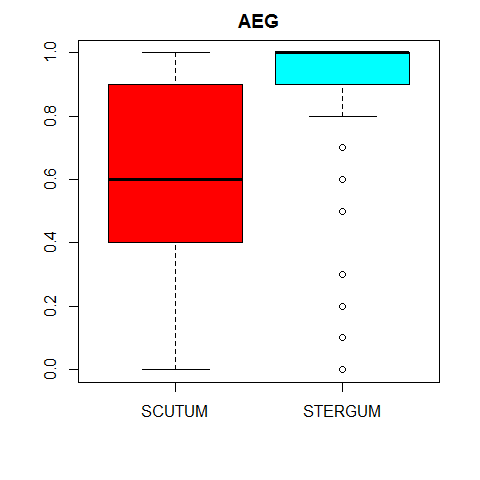

```r
boxplot(AEG[,4:5], col=rainbow(2), main="AEG")
```

### AEG Data Distribution

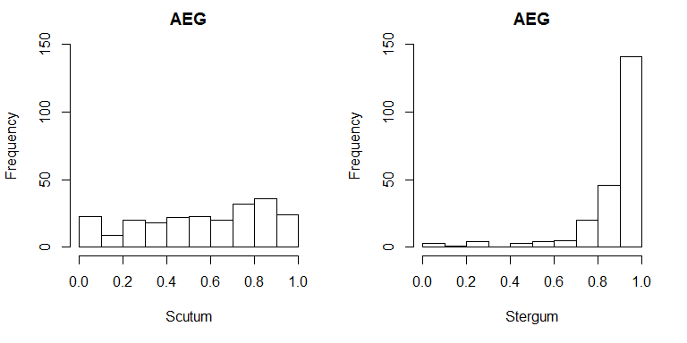

```r
par(mfrow=c(1,2))
hist(AEG$SCUTUM, xlab="Scutum", main="AEG", ylim = c(0, 150))
hist(AEG$STERGUM, xlab="Stergum", main="AEG", ylim = c(0, 150))
```

### AEG Data Chi-Square Test for Independence

```r
pander(chisq.test(AEGMosaic), caption = "Table 6. AEG Chi-Square Test for Independence", split.table = Inf)
```

```
-------------------------------
 Test statistic   df   P value
---------------- ---- ---------
     111.2        90   0.06401
-------------------------------

Table: Table 6. AEG Chi-Square Test for Independence
```

### AEG Data Mosaic Plot

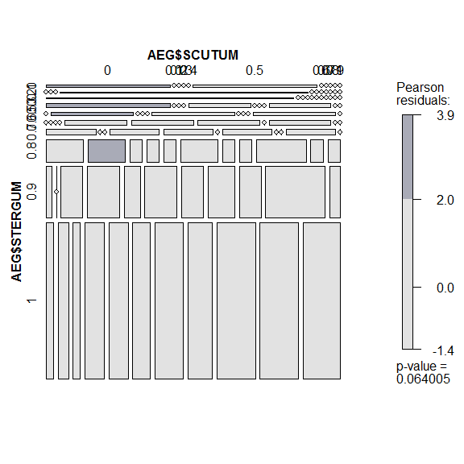

```r
mosaic(AEGMosaic, shade = TRUE)
```

### AEG Analysis Discussion

When looking at the AEG species, the stergum dataset appears to be heavily skewed while the scutum appears to be closer to normal. Table 6 and Figure 8 indicate that there are no significant differences between AEG scutum and stregum coverages at the 0.05 level.

## ALB Analysis

### ALB Data Summary

```r
pander(summary(ALB[,4:5]), caption = "Table 7. Summary of ALB Dataset")
```

```
--------------------------------
     SCUTUM          STERGUM
---------------- ---------------
 Min.  :0.0000    Min.  :0.000

 1st Qu.:0.1000   1st Qu.:0.800

 Median :0.1000   Median :1.000

  Mean :0.2778     Mean :0.856

 3rd Qu.:0.4000   3rd Qu.:1.000

 Max.  :1.0000    Max.  :1.000
--------------------------------

Table: Table 7. Summary of ALB Dataset
```

### ALB Data Description

```r
pander(describe(ALB[,4:5]), caption = "Table 8. Description of ALB Dataset")
```

```
-------------------------------------------------------------------------------
   &nbsp;      vars    n      mean      sd     median   trimmed    mad     min
------------- ------ ------ -------- -------- -------- --------- -------- -----
 **SCUTUM**     1     1014   0.2778   0.3049    0.1     0.2287    0.1483    0

 **STERGUM**    2     1014   0.856    0.2349     1      0.9121      0       0
-------------------------------------------------------------------------------

Table: Table 8. Description of ALB Dataset (continued below)


----------------------------------------------------------
   &nbsp;      max   range    skew    kurtosis      se
------------- ----- ------- -------- ---------- ----------
 **SCUTUM**     1      1     1.205     0.1296    0.009575

 **STERGUM**    1      1     -1.886    2.623     0.007378
----------------------------------------------------------
```

### ALB Data Frequency Counts

```r
pander(ftable(ALBMosaic), caption = "Table 9. ALB Frequencies", split.table = Inf)
```

```
------------- ------------ ---- ----- ----- ----- ----- ----- ----- ----- ----- ----- ----
               ALB$SCUTUM   0    0.1   0.2   0.3   0.4   0.5   0.6   0.7   0.8   0.9   1

 ALB$STERGUM

      0                     1     1     1     0     0     0     0     0     1     0    0

     0.1                    5     4     4     0     0     1     0     1     0     2    2

     0.2                    10    3     8     0     1     0     1     0     0     2    1

     0.3                    12    7     3     2     0     1     0     0     1     0    0

     0.4                    9     0     1     0     0     1     3     0     0     0    1

     0.5                    15    9     7     4     0     5     1     0     0     2    2

     0.6                    4    10     3     1     0     0     1     1     1     1    0

     0.7                    6    10     3     0     1     2     0     0     1     0    0

     0.8                    28   39     9     8     4     4     2     2     5     2    0

     0.9                    39   60    21    15    11     5     7     3     6    13    1

      1                     70   186   78    48    14    25    17     9    29    30    44
------------- ------------ ---- ----- ----- ----- ----- ----- ----- ----- ----- ----- ----

Table: Table 9. ALB Frequencies
```

### ALB Data Dispersion

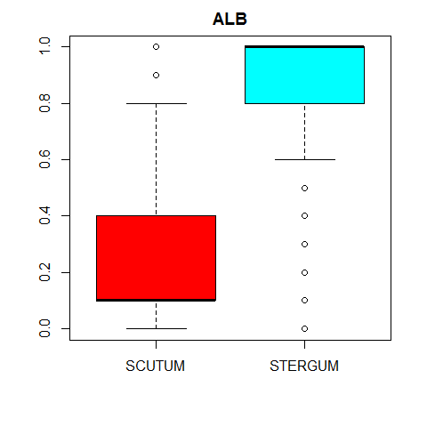

```r
boxplot(ALB[,4:5], col=rainbow(2), main="ALB")
```

### ALB Data Distribution

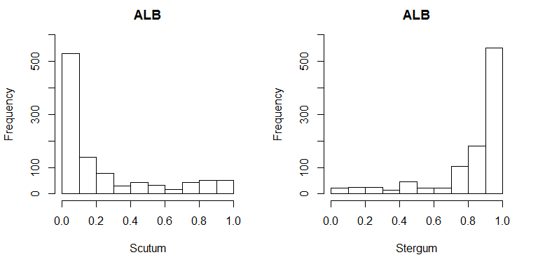

```r
par(mfrow=c(1,2))
hist(ALB$SCUTUM, xlab="Scutum", main="ALB", ylim = c(0, 600))
hist(ALB$STERGUM, xlab="Stergum", main="ALB", ylim = c(0, 600))
```

### ALB Data Chi-Square Test for Independence

```r
pander(chisq.test(ALBMosaic), caption = "Table 10. ALB Chi-Square Test for Independence", split.table = Inf)
```

```
----------------------------------------
 Test statistic   df        P value
---------------- ----- -----------------
     168.8        100   2.073e-05 * * *
----------------------------------------

Table: Table 10. ALB Chi-Square Test for Independence
```

### ALB Data Mosaic Plot

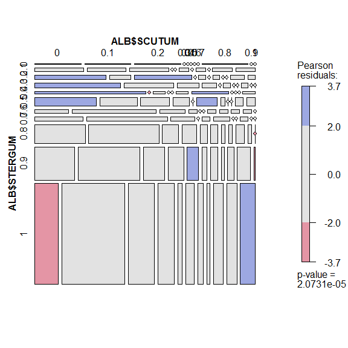

```r
mosaic(ALBMosaic, shade = TRUE)
```

## Between Species Data (AEG and ALB)

### Between Species Data Frequency Counts

```r
pander(ftable(StergumMosaic), caption = "Table 11. Stergum Frequencies", split.table = Inf)
```

```
--------- --------- --- ----- ----- ----- ----- ----- ----- ----- ----- ----- -----
           STERGUM   0   0.1   0.2   0.3   0.4   0.5   0.6   0.7   0.8   0.9    1

 SPECIES

   AEG               2    1     1     4     0     3     4     5    20    46    141

   ALB               4   19    26    26    15    45    22    23    103   181   550
--------- --------- --- ----- ----- ----- ----- ----- ----- ----- ----- ----- -----

Table: Table 11. Stergum Frequencies
```

```r
pander(ftable(ScutumMosaic), caption = "Table 12. Scutum Frequencies", split.table = Inf)
```

```
--------- -------- ----- ----- ----- ----- ----- ----- ----- ----- ----- ----- ----
           SCUTUM    0    0.1   0.2   0.3   0.4   0.5   0.6   0.7   0.8   0.9   1

 SPECIES

   AEG              13    10     9    20    18    22    23    20    32    36    24

   ALB              199   329   138   78    31    44    32    16    44    52    51
--------- -------- ----- ----- ----- ----- ----- ----- ----- ----- ----- ----- ----

Table: Table 12. Scutum Frequencies
```

### Between Species Data Scutum Distribution

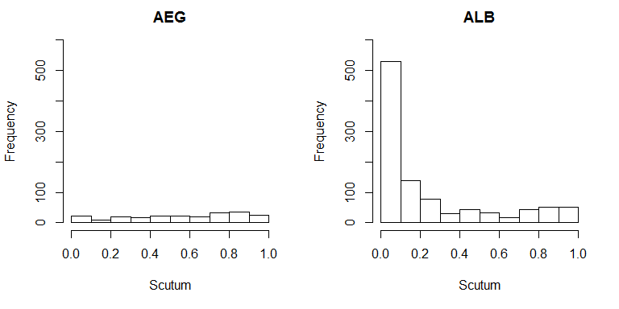

```r
par(mfrow=c(1,2))
hist(sternite$SCUTUM[sternite$SPECIES=="AEG"], xlab="Scutum", main="AEG", ylim = c(0, 600))
hist(sternite$SCUTUM[sternite$SPECIES=="ALB"], xlab="Scutum", main="ALB", ylim = c(0, 600))
```

### Between Species Data Scutum Distribution - Stacked

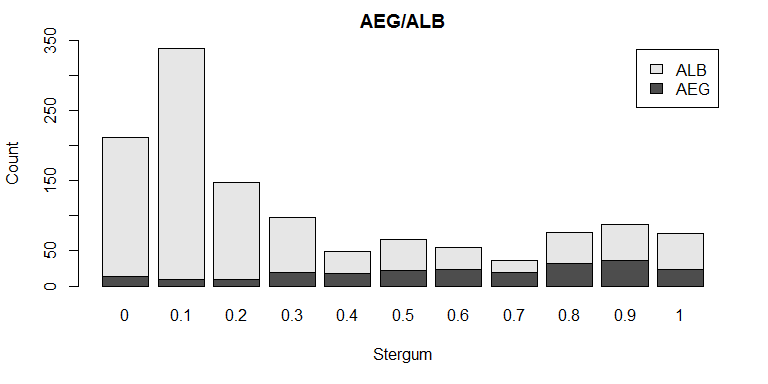

```r
barplot(ScutumMosaic, beside=FALSE, legend.text=TRUE, xlab="Stergum", ylab="Count", main="AEG/ALB", ylim = c(0, 350))
```

### Between Species Data Scutum Spine Plot

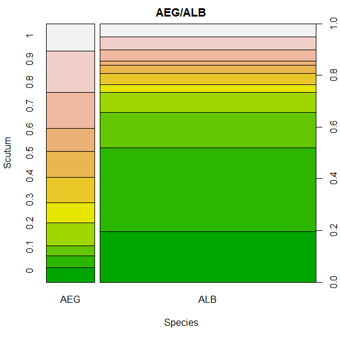

```r
spineplot(ScutumMosaic2, xlab="Species", ylab="Scutum", main="AEG/ALB", col = terrain.colors(11))
```

### Between Species Data Scutum Chi-Square Test for Independence

```r
pander(chisq.test(ScutumMosaic), caption = "Table 13. Between Species Scutum Chi-Square Test for Independence", split.table = Inf)
```

```
---------------------------------------
 Test statistic   df       P value
---------------- ---- -----------------
     232.6        10   2.492e-44 * * *
---------------------------------------

Table: Table 13. Between Species Scutum Chi-Square Test for Independence
```

### Between Species Data Scutum Mosaic Plot

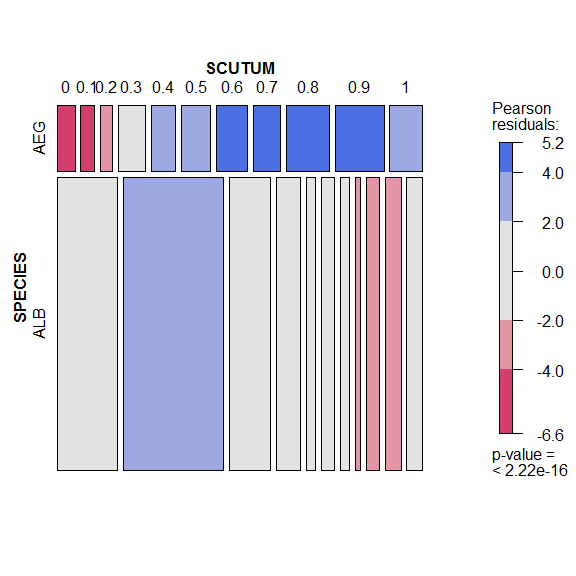

```r
mosaic(ScutumMosaic, shade = TRUE)
```

### Between Species Data Stergum Distribution

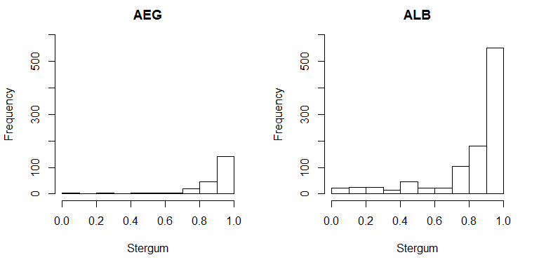

```r
par(mfrow=c(1,2))
hist(sternite$STERGUM[sternite$SPECIES=="AEG"], xlab="Stergum", main="AEG", ylim = c(0, 600))
hist(sternite$STERGUM[sternite$SPECIES=="ALB"], xlab="Stergum", main="ALB", ylim = c(0, 600))
```

### Between Species Data Stergum Distribution - Stacked

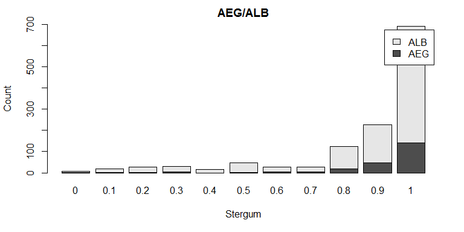

```r
barplot(StergumMosaic, beside=FALSE, legend.text=TRUE, xlab="Stergum", ylab="Count", main="AEG/ALB", ylim = c(0, 700))
```

### Between Species Data Stergum Spine Plot

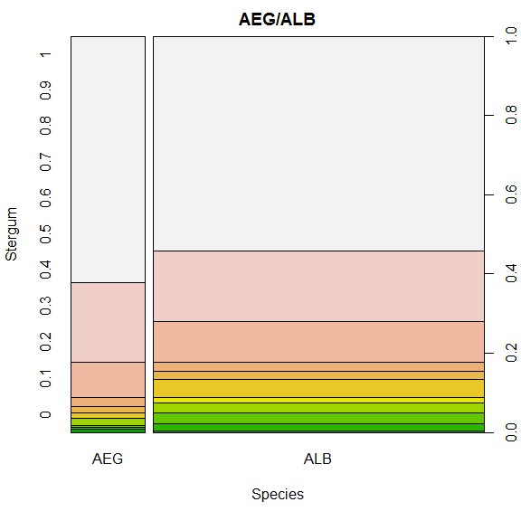

```r
spineplot(StergumMosaic2, xlab="Species", ylab="Stergum", main="AEG/ALB", col = terrain.colors(11))
```

### Between Species Data Stergum Chi-Square Test for Independence

```r
pander(chisq.test(StergumMosaic), caption = "Table 14. Between Species Stergum Chi-Square Test for Independence", split.table = Inf)
```

```
---------------------------------
 Test statistic   df    P value
---------------- ---- -----------
     18.77        10   0.04326 *
---------------------------------

Table: Table 14. Between Species Stergum Chi-Square Test for Independence
```

### Between Species Data Stergum Mosaic Plot

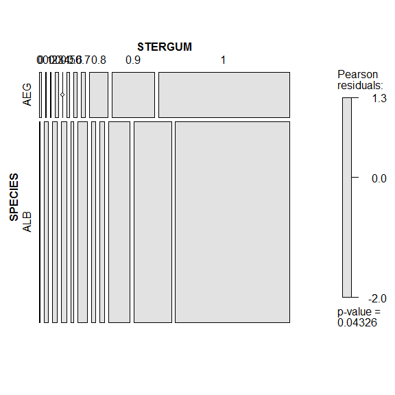

```r
mosaic(StergumMosaic, shade = TRUE)
```

### Between Species Analysis Discussion

When looking between the AEG and ALB species, the stergum datasets appear to be heavily skewed in the same direction while the scutum datstets appear to be different between species. **Table 13** indicates that there are *significant differences between AEG and ALB species scutum coverages* at the 0.05 and 0.01 level. **Figure 15** shows that range of 0.6 - 0.9 scutum coverages for AEG had *significantly more* values than expected and the range of 0.0 - 0.1 scutum coverages for AEG had *significantly less* values than expected. **Figure 15** also indicates that for ALB the range of 0.7 - 0.9 scutum coverages had *less* values than expected **Table 14** indicates that there are *significant differences between AEG and ALB species stergum coverages* at the 0.05 level. **Figure 19** shows that no coverages for either species had *significantly* more or less values than expected.